# Lending Loan

This is the business problem from Lending-club . Dataset is available for download from Kaggle - [dataset](https://www.kaggle.com/wendykan/lending-club-loan-data)

**Business Problem** : Find out the Loan which has chances of getting default or Model which predict the defaulter loan in future

To solve the problem , we can divide it into below parts.

1. Import the Libraries
2. Load the Dataset
3. Perform EDA on dataset
4. Data PreProcessing
5. Feature Engineering
6. Applying ML algorithm with pipeline
7. Finding the best performing Algorithm
8. Parameter tuning for Algorithm
9. Training the data on Algorithm
10. Predicting the output

Lets get started and explore more dataset import the required library for analysis and Machine learning

```python
#Import libraries
import pandas as pd
import numpy as np
import scipy
import seaborn as sns
import matplotlib.pyplot as plt
import warnings
import pickle
import re

#sklearn libraries
from sklearn.linear_model import LogisticRegression
from sklearn.model_selection import train_test_split
from sklearn.svm import SVC
from sklearn.naive_bayes import GaussianNB
from sklearn.tree import DecisionTreeClassifier
from sklearn.neighbors import KNeighborsClassifier
from sklearn.model_selection import KFold
from sklearn.model_selection import cross_val_score
from sklearn.preprocessing import StandardScaler,LabelEncoder
from sklearn.pipeline import Pipeline
from sklearn.model_selection import GridSearchCV
from sklearn.ensemble import ExtraTreesClassifier
#from sklearn.model_selection import GridSearchCV
from sklearn.ensemble import AdaBoostClassifier
from sklearn.ensemble import GradientBoostingClassifier
from sklearn.ensemble import RandomForestClassifier
from sklearn.metrics import accuracy_score
from sklearn.metrics import confusion_matrix
from sklearn.metrics import classification_report
from sklearn.metrics import roc_curve, auc,roc_auc_score
```

```python
warnings.filterwarnings("ignore")
```

1. Load the dataset from Disk and create copy of the dataset so that we can start analysis of it make changes on it.
2. To load it faster we can dump the dataset and load it from pickle file
3. with head() we can get first few rows of dataset and get some idea about the dataset
4. dataset has ~880K rows and 74 columns in dataset
5. with info(), dataset has mix number of features and have missing values
6. while looking into dataset , load_status is our target variable for which we need to perform prediction

```python
#Load the Dataset
dt_train_original=pd.read_csv("loan.csv",sep=',')
dt_train=dt_train_original.copy()
#pd.set_option('display.max_columns', None)
```

```python
#Pickle to load fast
with open('dt_train.pickle','wb') as f:
    pickle.dump(dt_train,f)

dt_train1=open('dt_train.pickle','rb')
dt_train=pickle.load(dt_train1)
```

```python
#Display first 5 rows of Dataset
dt_train.head(5)
```

|  | id | member_id | loan_amnt | funded_amnt | funded_amnt_inv | term | int_rate | installment | grade | sub_grade | ... | total_bal_il | il_util | open_rv_12m | open_rv_24m | max_bal_bc | all_util | total_rev_hi_lim | inq_fi | total_cu_tl | inq_last_12m |
| --- | --- | --- | --- | --- | --- | --- | --- | --- | --- | --- | --- | --- | --- | --- | --- | --- | --- | --- | --- | --- | --- |
| 0 | 1077501 | 1296599 | 5000.0 | 5000.0 | 4975.0 | 36 months | 10.65 | 162.87 | B | B2 | ... | NaN | NaN | NaN | NaN | NaN | NaN | NaN | NaN | NaN | NaN |
| 1 | 1077430 | 1314167 | 2500.0 | 2500.0 | 2500.0 | 60 months | 15.27 | 59.83 | C | C4 | ... | NaN | NaN | NaN | NaN | NaN | NaN | NaN | NaN | NaN | NaN |
| 2 | 1077175 | 1313524 | 2400.0 | 2400.0 | 2400.0 | 36 months | 15.96 | 84.33 | C | C5 | ... | NaN | NaN | NaN | NaN | NaN | NaN | NaN | NaN | NaN | NaN |
| 3 | 1076863 | 1277178 | 10000.0 | 10000.0 | 10000.0 | 36 months | 13.49 | 339.31 | C | C1 | ... | NaN | NaN | NaN | NaN | NaN | NaN | NaN | NaN | NaN | NaN |
| 4 | 1075358 | 1311748 | 3000.0 | 3000.0 | 3000.0 | 60 months | 12.69 | 67.79 | B | B5 | ... | NaN | NaN | NaN | NaN | NaN | NaN | NaN | NaN | NaN | NaN |

5 rows × 74 columns

```python
#Dispaly shape and size of Dataset
dt_train.shape
```

```
(887379, 74)
```

```python
#Display datatypre and number of rows and missing values in columns
dt_train.info()
```

```
<class 'pandas.core.frame.DataFrame'>
RangeIndex: 887379 entries, 0 to 887378
Data columns (total 74 columns):
id                             887379 non-null int64
member_id                      887379 non-null int64
loan_amnt                      887379 non-null float64
funded_amnt                    887379 non-null float64
funded_amnt_inv                887379 non-null float64
term                           887379 non-null object
int_rate                       887379 non-null float64
installment                    887379 non-null float64
grade                          887379 non-null object
sub_grade                      887379 non-null object
emp_title                      835917 non-null object
emp_length                     842554 non-null object
home_ownership                 887379 non-null object
annual_inc                     887375 non-null float64
verification_status            887379 non-null object
issue_d                        887379 non-null object
loan_status                    887379 non-null object
pymnt_plan                     887379 non-null object
url                            887379 non-null object
desc                           126028 non-null object
purpose                        887379 non-null object
title                          887227 non-null object
zip_code                       887379 non-null object
addr_state                     887379 non-null object
dti                            887379 non-null float64
delinq_2yrs                    887350 non-null float64
earliest_cr_line               887350 non-null object
inq_last_6mths                 887350 non-null float64
mths_since_last_delinq         433067 non-null float64
mths_since_last_record         137053 non-null float64
open_acc                       887350 non-null float64
pub_rec                        887350 non-null float64
revol_bal                      887379 non-null float64
revol_util                     886877 non-null float64
total_acc                      887350 non-null float64
initial_list_status            887379 non-null object
out_prncp                      887379 non-null float64
```

[output cut: 24 more lines]

```
open_il_12m                    21372 non-null float64
open_il_24m                    21372 non-null float64
mths_since_rcnt_il             20810 non-null float64
total_bal_il                   21372 non-null float64
il_util                        18617 non-null float64
open_rv_12m                    21372 non-null float64
open_rv_24m                    21372 non-null float64
max_bal_bc                     21372 non-null float64
all_util                       21372 non-null float64
total_rev_hi_lim               817103 non-null float64
inq_fi                         21372 non-null float64
total_cu_tl                    21372 non-null float64
inq_last_12m                   21372 non-null float64
dtypes: float64(49), int64(2), object(23)
memory usage: 501.0+ MB
```

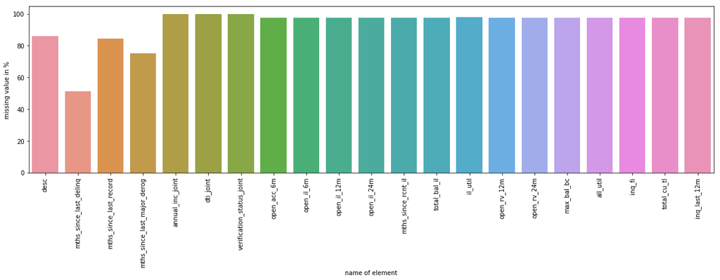

```
(887379, 53)
```

```python
# Display , plot and delete columns has missing value more than 50%
col_name=dt_train.columns
column_name=[]
numbers=[]
missval=dt_train.isnull().sum()/len(dt_train)*100

for i in range(0,74):
    if missval[i]>50:
        column_name.append(col_name[i])
        numbers.append(missval[i])
frame={'name of element':column_name,'missing value in %':numbers}
df_miss=pd.DataFrame(frame)
plt.figure(figsize=(20,5))
sns.barplot(x='name of element',y='missing value in %',data=df_miss)
plt.xticks(rotation=90)
plt.show()


#drop the columns
dt_train.drop(column_name,inplace=True,axis=1)
dt_train.shape
```

```python
#short summary abd description of All columns
dt_train.describe(include='all')
```

|  | id | member_id | loan_amnt | funded_amnt | funded_amnt_inv | term | int_rate | installment | grade | sub_grade | ... | last_pymnt_amnt | next_pymnt_d | last_credit_pull_d | collections_12_mths_ex_med | policy_code | application_type | acc_now_delinq | tot_coll_amt | tot_cur_bal | total_rev_hi_lim |
| --- | --- | --- | --- | --- | --- | --- | --- | --- | --- | --- | --- | --- | --- | --- | --- | --- | --- | --- | --- | --- | --- |
| count | 8.873790e+05 | 8.873790e+05 | 887379.000000 | 887379.000000 | 887379.000000 | 887379 | 887379.000000 | 887379.000000 | 887379 | 887379 | ... | 887379.000000 | 634408 | 887326 | 887234.000000 | 887379.0 | 887379 | 887350.000000 | 8.171030e+05 | 8.171030e+05 | 8.171030e+05 |
| unique | NaN | NaN | NaN | NaN | NaN | 2 | NaN | NaN | 7 | 35 | ... | NaN | 100 | 103 | NaN | NaN | 2 | NaN | NaN | NaN | NaN |
| top | NaN | NaN | NaN | NaN | NaN | 36 months | NaN | NaN | B | B3 | ... | NaN | Feb-2016 | Jan-2016 | NaN | NaN | INDIVIDUAL | NaN | NaN | NaN | NaN |
| freq | NaN | NaN | NaN | NaN | NaN | 621125 | NaN | NaN | 254535 | 56323 | ... | NaN | 553406 | 730574 | NaN | NaN | 886868 | NaN | NaN | NaN | NaN |
| mean | 3.246513e+07 | 3.500182e+07 | 14755.264605 | 14741.877625 | 14702.464383 | NaN | 13.246740 | 436.717127 | NaN | NaN | ... | 2164.145585 | NaN | NaN | 0.014380 | 1.0 | NaN | 0.004991 | 2.257026e+02 | 1.394582e+05 | 3.206862e+04 |
| std | 2.282734e+07 | 2.411335e+07 | 8435.455601 | 8429.897657 | 8442.106732 | NaN | 4.381867 | 244.186593 | NaN | NaN | ... | 4794.783233 | NaN | NaN | 0.134191 | 0.0 | NaN | 0.077625 | 1.031137e+04 | 1.537500e+05 | 3.749826e+04 |
| min | 5.473400e+04 | 7.047300e+04 | 500.000000 | 500.000000 | 0.000000 | NaN | 5.320000 | 15.670000 | NaN | NaN | ... | 0.000000 | NaN | NaN | 0.000000 | 1.0 | NaN | 0.000000 | 0.000000e+00 | 0.000000e+00 | 0.000000e+00 |
| 25% | 9.206643e+06 | 1.087713e+07 | 8000.000000 | 8000.000000 | 8000.000000 | NaN | 9.990000 | 260.705000 | NaN | NaN | ... | 280.170000 | NaN | NaN | 0.000000 | 1.0 | NaN | 0.000000 | 0.000000e+00 | 2.985300e+04 | 1.390000e+04 |
| 50% | 3.443327e+07 | 3.709528e+07 | 13000.000000 | 13000.000000 | 13000.000000 | NaN | 12.990000 | 382.550000 | NaN | NaN | ... | 462.780000 | NaN | NaN | 0.000000 | 1.0 | NaN | 0.000000 | 0.000000e+00 | 8.055900e+04 | 2.370000e+04 |
| 75% | 5.490814e+07 | 5.847135e+07 | 20000.000000 | 20000.000000 | 20000.000000 | NaN | 16.200000 | 572.600000 | NaN | NaN | ... | 831.245000 | NaN | NaN | 0.000000 | 1.0 | NaN | 0.000000 | 0.000000e+00 | 2.082050e+05 | 3.980000e+04 |
| max | 6.861706e+07 | 7.354484e+07 | 35000.000000 | 35000.000000 | 35000.000000 | NaN | 28.990000 | 1445.460000 | NaN | NaN | ... | 36475.590000 | NaN | NaN | 20.000000 | 1.0 | NaN | 14.000000 | 9.152545e+06 | 8.000078e+06 | 9.999999e+06 |

11 rows × 53 columns

After deleting the columns we still have lot of missing values , lets look into below#

```python
#Handling missing values:
dt_train.isnull().sum()
```

```
id                                 0
member_id                          0
loan_amnt                          0
funded_amnt                        0
funded_amnt_inv                    0
term                               0
int_rate                           0
installment                        0
grade                              0
sub_grade                          0
emp_title                      51462
emp_length                     44825
home_ownership                     0
annual_inc                         4
verification_status                0
issue_d                            0
loan_status                        0
pymnt_plan                         0
url                                0
purpose                            0
title                            152
zip_code                           0
addr_state                         0
dti                                0
delinq_2yrs                       29
earliest_cr_line                  29
inq_last_6mths                    29
open_acc                          29
pub_rec                           29
revol_bal                          0
revol_util                       502
total_acc                         29
initial_list_status                0
out_prncp                          0
out_prncp_inv                      0
total_pymnt                        0
total_pymnt_inv                    0
total_rec_prncp                    0
total_rec_int                      0
total_rec_late_fee                 0
recoveries                         0
collection_recovery_fee            0
last_pymnt_d                   17659
last_pymnt_amnt                    0
next_pymnt_d                  252971
last_credit_pull_d                53
collections_12_mths_ex_med       145
policy_code                        0
application_type                   0
acc_now_delinq                    29
tot_coll_amt                   70276
tot_cur_bal                    70276
total_rev_hi_lim               70276
dtype: int64
```

1. for columns 'emp_lenght' and 'term' has object datatype , let's convert both columns into float data type .
2. we are replacing string and some symbols with nothing and them convert it into float data type

```python
dt_train['emp_length']=dt_train['emp_length'].str.replace('year','')
dt_train['emp_length']=dt_train['emp_length'].str.replace('s','')
dt_train['emp_length']=dt_train['emp_length'].str.replace('+','')
dt_train['emp_length']=dt_train['emp_length'].str.replace('<','')
dt_train['emp_length']=dt_train['emp_length'].str.replace('>','')
dt_train['term']=dt_train['term'].str.replace('months','')

dt_train['emp_length']=dt_train['emp_length'].astype('float')
dt_train['term']=dt_train['term'].astype('float')
```

1. most of the columns has numerical feature and we are going to fill all those missing value with median value of that column
2. For the date columns we are going to fill missing values with most frequent avaible date time

```python
replace={'total_rev_hi_lim':dt_train['total_rev_hi_lim'].median(),'tot_cur_bal':dt_train['tot_cur_bal'].median(),
         'tot_coll_amt':dt_train['tot_coll_amt'].median(),'acc_now_delinq':dt_train['acc_now_delinq'].median(),'collections_12_mths_ex_med':dt_train['collections_12_mths_ex_med'].median(),
        'total_acc':dt_train['total_acc'].median(),
        'revol_util':dt_train['revol_util'].median(),'pub_rec':dt_train['pub_rec'].median(),'open_acc':dt_train['open_acc'].median(),
        'inq_last_6mths':dt_train['inq_last_6mths'].median(),
        'delinq_2yrs':dt_train['delinq_2yrs'].median(),'tittle':'Debt consolidation',
        'emp_title':'Teacher','emp_length':dt_train['emp_length'].median(),'annual_inc':dt_train['annual_inc'].median()}

replace_date={'last_credit_pull_d':'Jan-2016','next_pymnt_d':'Feb-2016','last_pymnt_d':'Jan-2016','earliest_cr_line':'Aug-2001','title':'Debt consolidation'}
dt_train.fillna(replace,inplace=True)
dt_train.fillna(replace_date,inplace=True)
```

1. with isnull() we got false value, it means there is no any other missing value present in dataset

```python
dt_train.isnull().any().any()
```

```
False
```

1. with below counterplot, we can state that dataset is inbalanced
2. Most of the values present in dataset has current loan
3. Almost 200K values has Fully paid loan
4. ~45 K values has loan status of charged off
5. only 1219 values has default loan status
6. lets understand the target variable , we have to find out defaulter, so we can remove all loan status except (to train ML algo) 'fully paid', 'charged off', 'default'.
7. by the defination of chared off in loan we can consider that 'charge off' also one type of default So we need to change charge off also to default

```
Current                                                601779
Fully Paid                                             207723
Charged Off                                             45248
Late (31-120 days)                                      11591
Issued                                                   8460
In Grace Period                                          6253
Late (16-30 days)                                        2357
Does not meet the credit policy. Status:Fully Paid       1988
Default                                                  1219
Does not meet the credit policy. Status:Charged Off       761
Name: loan_status, dtype: int64
```

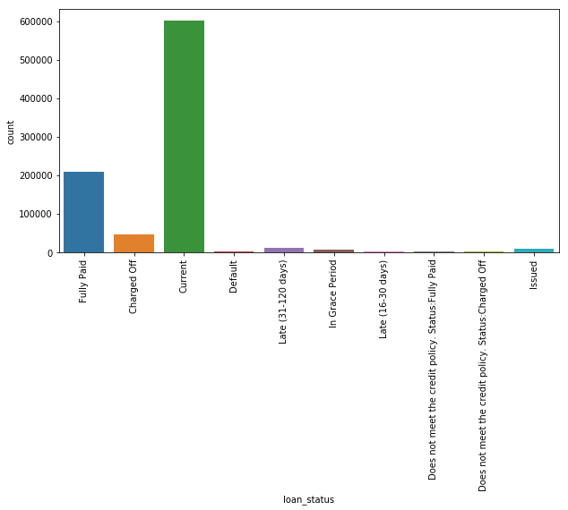

```python
#Target variable
loan_stat=dt_train['loan_status'].value_counts()
print(loan_stat)
plt.figure(figsize=(10,5))
sns.countplot('loan_status',data=dt_train)
plt.xticks(rotation=90)
plt.show()
```

```python
#delete other categorical variable from 'loan' status except
new_frame=dt_train[dt_train['loan_status'] == 'Current'].index
list1=['Late (31-120 days)','In Grace Period','Late (16-30 days)','Does not meet the credit policy. Status:Fully Paid',
      'Does not meet the credit policy. Status:Charged Off','Issued']

for i in list1:
    r1=dt_train[dt_train['loan_status'] == i].index
    dt_train.drop(r1,inplace=True)

new_frame1=pd.DataFrame(new_frame)
dt_train.drop(new_frame,inplace=True)
```

```python
#change charge off tu default
dt_train['loan_status'].replace('Charged Off','Default',inplace=True)
```

1. Now all missing value we have handled, now let's look into its correlation with each other ,so that we can find out which feature is highly correlated and we can remove one .
2. with the corr() and heatmap(), we can find correlation and plot it to understand better
3. From below , 'id' & 'member_id' are highly correlated
4. 'loan_amnt', 'funded_amnt','funded_amnt_inv' are very highly correlated
5. 'total_paymnt','total_paynt_inv','total_rec_prncp' are very highly correlated
6. Also there are some other feauture which has correlated more than 80% , we also look into that and understand it and if require we will remove

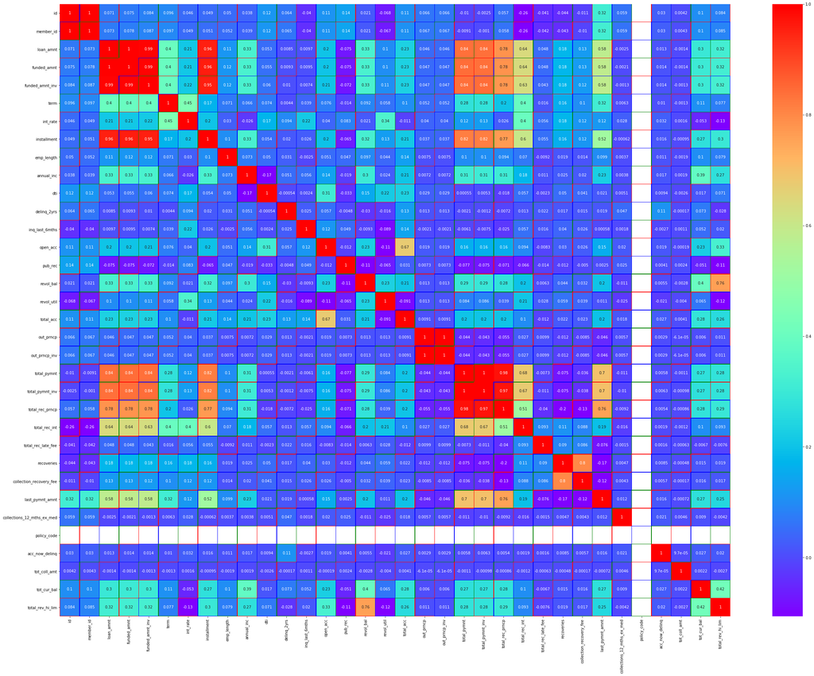

```python
dt_corr=dt_train.corr()
dt_corr1=[]
plt.figure(figsize=(40,30))
sns.heatmap(dt_corr,linewidth=0.5,cmap="rainbow",annot=True,robust=True,linecolor="rbg")
plt.show()
```

```python
#delete highly correlated columns
dt_train.drop(['member_id','funded_amnt','funded_amnt_inv','out_prncp_inv','total_rec_prncp','total_pymnt_inv','url','sub_grade','title','emp_title','zip_code','next_pymnt_d','last_credit_pull_d','id'],axis=1,inplace=True)
```

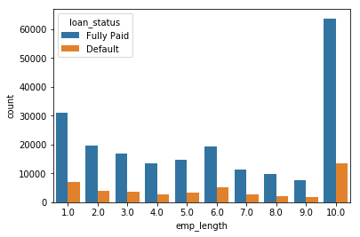

```python
dt_train.groupby(['loan_status','emp_length'])['loan_status'].count()
sns.countplot('emp_length',hue='loan_status',data=dt_train)
plt.show()
```

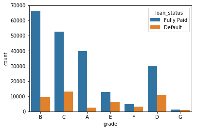

```python
sns.countplot('grade',hue='loan_status',data=dt_train)
plt.show()
```

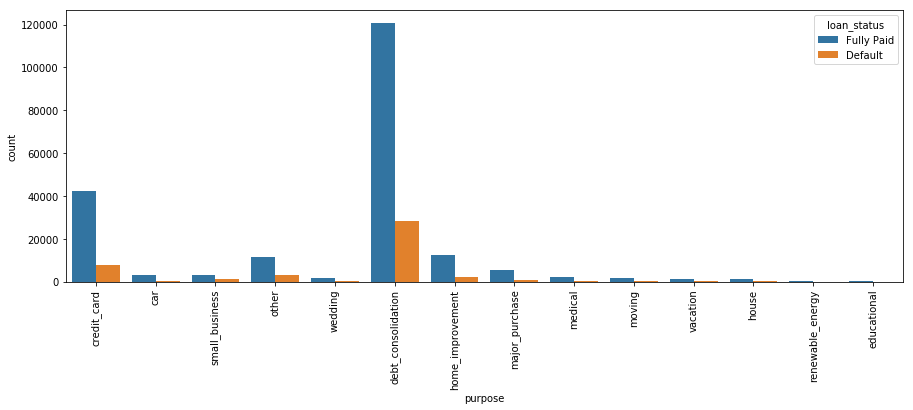

```python
plt.figure(figsize=(15,5))
sns.countplot('purpose',hue='loan_status',data=dt_train)
plt.xticks(rotation=90)
plt.show()
```

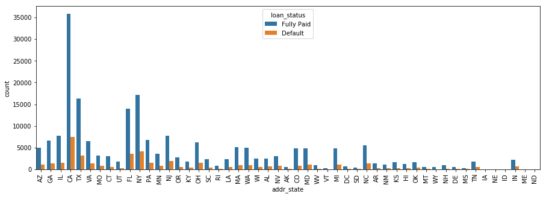

```python
plt.figure(figsize=(15,5))
sns.countplot('addr_state',hue='loan_status',data=dt_train)
plt.xticks(rotation=90)
plt.show()
```

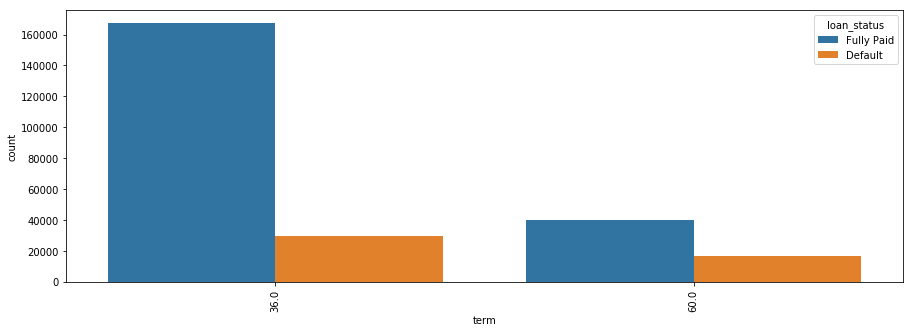

```python
plt.figure(figsize=(15,5))
sns.countplot('term',hue='loan_status',data=dt_train)
plt.xticks(rotation=90)
plt.show()
```

Let's work on some vizualization part and try to understand distrubution of data

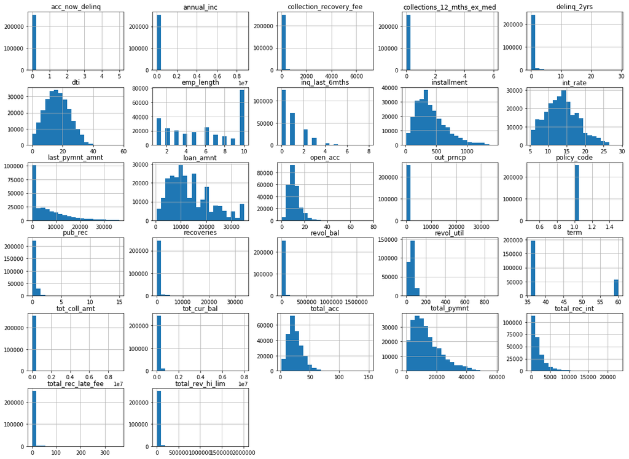

```python
dt_train.hist(bins=20, figsize=(20, 15))
plt.show()
```

```python
dt_train['issue_d']=pd.to_datetime(dt_train['issue_d'])
dt_train['earliest_cr_line']=pd.to_datetime(dt_train['earliest_cr_line'])
dt_train['last_pymnt_d']=pd.to_datetime(dt_train['last_pymnt_d'])
```

```python
dt_train['issue_d_year']=dt_train['issue_d'].dt.year
dt_train['issue_d_month']=dt_train['issue_d'].dt.month
dt_train['earliest_cr_line_year']=dt_train['issue_d'].dt.year
dt_train['earliest_cr_line_month']=dt_train['issue_d'].dt.month
dt_train['last_pymnt_d_year']=dt_train['issue_d'].dt.year
dt_train['last_pymnt_d_month']=dt_train['issue_d'].dt.month
dt_train.drop(['issue_d','earliest_cr_line','last_pymnt_d'],inplace=True,axis=1)
```

```
['loan_amnt', 'term', 'int_rate', 'installment', 'emp_length', 'annual_inc', 'dti', 'delinq_2yrs', 'inq_last_6mths', 'open_acc', 'pub_rec', 'revol_bal', 'revol_util', 'total_acc', 'out_prncp', 'total_pymnt', 'total_rec_int', 'total_rec_late_fee', 'recoveries', 'collection_recovery_fee', 'last_pymnt_…
[ 8.34040853e-01  1.32729167e+00  3.44966702e-01  1.00914591e+00
 -9.05970704e-02  4.07645770e+01  2.10787330e-01  5.80732525e+00
  1.42060838e+00  1.13148419e+00  4.88876557e+00  1.41019411e+01
 -7.56501394e-02  8.10027782e-01  2.12379650e+01  1.06147091e+00
  2.60244269e+00  1.31223613e+01  9.60286550e+00  1.56686638e+01
  1.44379536e+00  1.60617900e+01  0.00000000e+00  2.42740206e+01
  4.99595806e+02  4.01882589e+00  9.56920897e+00 -7.98112924e-01
 -6.03515849e-02 -7.98112924e-01 -6.03515849e-02 -7.98112924e-01
 -6.03515849e-02]
```

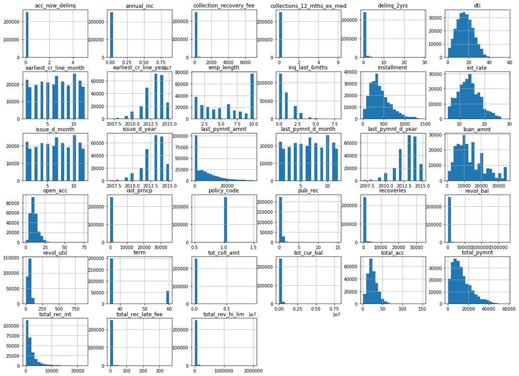

```python
# Skewness
col_number = dt_train.select_dtypes(include=['number']).columns.tolist()
print(col_number)
for col_transform in col_number:
    skewness = scipy.stats.skew(dt_train[col_number])
print(skewness)
if skewness.all() > 0.75:
    dt_train[col_number] = np.log1p(dt_train[col_number])

dt_train.hist(bins=20, figsize=(20, 15))
plt.show()
```

1. In our target variable, there are only 2 categories , 'fully paid' & 'Default'
2. before creating dummy variable , lets convert target variable into numerical in form of 0 & 1
3. Now we have done with EDA part and require to create Dummy variable for categorical feature
4. After applying get_dummies now we have almost 113 features in our dataset

```python
dt_train['loan_status']=dt_train['loan_status'].apply(lambda x: 0 if x=='Fully Paid' else 1)
```

```python
dt_train=pd.get_dummies(dt_train,drop_first=True)
dt_train.shape
```

```
(254190, 113)
```

Let's create pockle file of dataset which contain all the changes still we have done on it , so that from next time we can dorectly start from here if we want to run the analysis again

```python
with open('dt_train_complete.pickle','wb') as f:
    pickle.dump(dt_train,f)

dt_train_complete1=open('dt_train_complete.pickle','rb')
dt_train=pickle.load(dt_train_complete1)
```

Lets splete the dataset for training and testing purpose , generally we split dataset in 80:20 ratio, but here dataset is large in size , so to male it faster for trainng we can split it into 60:40 ratio.

```python
#split dataset
X=dt_train.drop(['loan_status'],axis=1)
Y=dt_train['loan_status']

X_train,X_test,Y_train,Y_test=train_test_split(X,Y,random_state=7,test_size=0.40)
```

```python
%timeit
pipeEse=[]
pipeEse.append(('ScaledAdaB',Pipeline([('Scaler',StandardScaler()),('AdaB',AdaBoostClassifier())])))
pipeEse.append(('ScaledGB',Pipeline([('Scaler',StandardScaler()),('GB',GradientBoostingClassifier())])))
pipeEse.append(('ScaledRFR',Pipeline([('Scaler',StandardScaler()),('RFR',RandomForestClassifier())])))
pipeEse.append(('ScaledETR',Pipeline([('Scaler',StandardScaler()),('ETR',ExtraTreesClassifier())])))

names=[]
result=[]
for name,model in pipeEse:
    kfolds=KFold(n_splits=10,random_state=7,)
    cv_results=cross_val_score(model,X_train,Y_train,cv=kfolds,scoring='accuracy',n_jobs=-1)
    result.append(cv_results)
    names.append(name)
    print(name, cv_results.mean() ,cv_results.std())
```

```
ScaledAdaB 0.992820331240871 0.0006777525998502281
ScaledGB 0.9938169493660096 0.0006700773043231441
ScaledRFR 0.9883420589051157 0.0019516315526910924
ScaledETR 0.9714058803038512 0.003119636863041588
```

It's time apply Machine learning Algorithm on dataset and find out which algortihm gives best accuracy score with less standard deviation

1. Right now we don't know which algo best fit for this problem
2. we will create pipeline , in pipeline we will preprocess data with StandardScaler and on that will apply ML algorithms
3. As dataset is large in size , so better we will start with Ensembles ,
4. after generating the result with Ensembles, GradientBoostingClassifier performed best out ofv all.
5. GradientBoostingClassifier gives 99% accuracy with very less std score
6. so we will train and predict test datset with GradientBoostingClassifier

```python
scale=StandardScaler().fit(X_train)
tran=scale.transform(X_train)
model=GradientBoostingClassifier(random_state=7,n_estimators=100)
model.fit(tran,Y_train)

model.fit(tran,Y_train)
trnsF2=scale.transform(X_test)
decision=model.predict(trnsF2)
finalScore=accuracy_score(decision,Y_test)
finalScore1=confusion_matrix(decision,Y_test)
finalScore2=classification_report(decision,Y_test)
print(finalScore)
print(finalScore1)
print(finalScore2)
```

```
0.9934694519847358
[[83106   659]
 [    5 17906]]
              precision    recall  f1-score   support

           0       1.00      0.99      1.00     83765
           1       0.96      1.00      0.98     17911

   micro avg       0.99      0.99      0.99    101676
   macro avg       0.98      1.00      0.99    101676
weighted avg       0.99      0.99      0.99    101676
```

We get almost 99% accuracy score and confusion marix , classification report also look good

```python
finalScore3=roc_auc_score(Y_test,decision)
finalScore3
```

```
0.9822214683588635
```

```python
finalScore5=roc_curve(Y_test,decision)
finalScore5
```

```
(array([0.00000000e+00, 6.01605082e-05, 1.00000000e+00]),
 array([0.       , 0.9645031, 1.       ]),
 array([2, 1, 0], dtype=int64))
```

```python
false_positive_rate, true_positive_rate, thresholds = roc_curve(Y_test,decision)

finalScore4=auc(false_positive_rate, true_positive_rate)
finalScore4
```

```
0.9822214683588635
```

we can calculate AUC score also and it almost same of above